# Class JRootPane

java.lang.Object

java.awt.Component

java.awt.Container

javax.swing.JComponent

javax.swing.JRootPane

**All Implemented Interfaces:**

`ImageObserver, MenuContainer, Serializable, Accessible`

```java
public class JRootPane extends JComponent implements Accessible
```

A lightweight container used behind the scenes by `JFrame`, `JDialog`, `JWindow`, `JApplet`, and `JInternalFrame`. For task-oriented information on functionality provided by root panes see [How to Use Root Panes](https://docs.oracle.com/javase/tutorial/uiswing/components/rootpane.html), a section in *The Java Tutorial*.

The following image shows the relationships between the classes that use root panes.

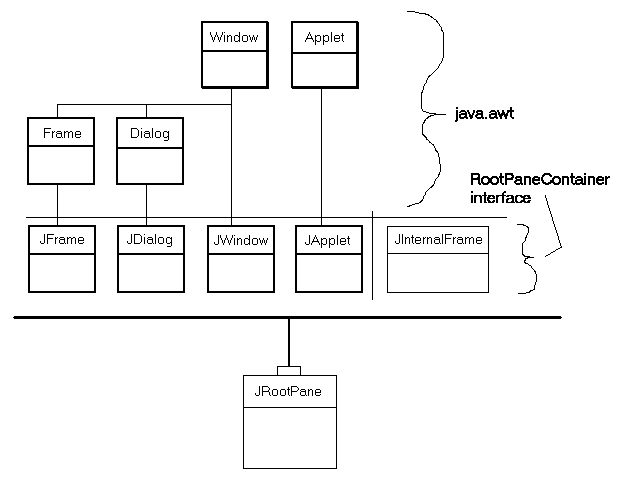

The "heavyweight" components (those that delegate to a peer, or native component on the host system) are shown with a darker, heavier box. The four heavyweight JFC/Swing containers (`JFrame`, `JDialog`, `JWindow`, and `JApplet`) are shown in relation to the AWT classes they extend. These four components are the only heavyweight containers in the Swing library. The lightweight container `JInternalFrame` is also shown. All five of these JFC/Swing containers implement the `RootPaneContainer` interface, and they all delegate their operations to a `JRootPane` (shown with a little "handle" on top).

> **Note:** The `JComponent` method `getRootPane` can be used to obtain the `JRootPane` that contains a given component.

Example:

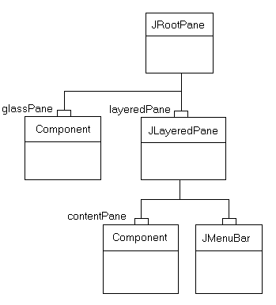

The diagram at right shows the structure of a `JRootPane`. A `JRootpane` is made up of a `glassPane`, an optional `menuBar`, and a `contentPane`. (The `JLayeredPane` manages the `menuBar` and the `contentPane`.) The `glassPane` sits over the top of everything, where it is in a position to intercept mouse movements. Since the `glassPane` (like the `contentPane`) can be an arbitrary component, it is also possible to set up the `glassPane` for drawing. Lines and images on the `glassPane` can then range over the frames underneath without being limited by their boundaries.

Although the `menuBar` component is optional, the `layeredPane`, `contentPane`, and `glassPane` always exist. Attempting to set them to `null` generates an exception.

To add components to the `JRootPane` (other than the optional menu bar), you add the object to the `contentPane` of the `JRootPane`, like this:

```
      rootPane.getContentPane().add(child);
```

The same principle holds true for setting layout managers, removing components, listing children, etc. All these methods are invoked on the `contentPane` instead of on the `JRootPane`.

> **Note:** The default layout manager for the `contentPane` is a `BorderLayout` manager. However, the `JRootPane` uses a custom `LayoutManager`. So, when you want to change the layout manager for the components you added to a `JRootPane`, be sure to use code like this:

> ```
>    rootPane.getContentPane().setLayout(new BoxLayout());
> ```

If a `JMenuBar` component is set on the `JRootPane`, it is positioned along the upper edge of the frame. The `contentPane` is adjusted in location and size to fill the remaining area. (The `JMenuBar` and the `contentPane` are added to the `layeredPane` component at the `JLayeredPane.FRAME_CONTENT_LAYER` layer.)

The `layeredPane` is the parent of all children in the `JRootPane` -- both as the direct parent of the menu and the grandparent of all components added to the `contentPane`. It is an instance of `JLayeredPane`, which provides the ability to add components at several layers. This capability is very useful when working with menu popups, dialog boxes, and dragging -- situations in which you need to place a component on top of all other components in the pane.

The `glassPane` sits on top of all other components in the `JRootPane`. That provides a convenient place to draw above all other components, and makes it possible to intercept mouse events, which is useful both for dragging and for drawing. Developers can use `setVisible` on the `glassPane` to control when the `glassPane` displays over the other children. By default the `glassPane` is not visible.

The custom `LayoutManager` used by `JRootPane` ensures that:

1. The `glassPane` fills the entire viewable area of the `JRootPane` (bounds - insets).
2. The `layeredPane` fills the entire viewable area of the `JRootPane`. (bounds - insets)
3. The `menuBar` is positioned at the upper edge of the `layeredPane`.
4. The `contentPane` fills the entire viewable area, minus the `menuBar`, if present.

Any other views in the `JRootPane` view hierarchy are ignored.

If you replace the `LayoutManager` of the `JRootPane`, you are responsible for managing all of these views. So ordinarily you will want to be sure that you change the layout manager for the `contentPane` rather than for the `JRootPane` itself!

The painting architecture of Swing requires an opaque `JComponent` to exist in the containment hierarchy above all other components. This is typically provided by way of the content pane. If you replace the content pane, it is recommended that you make the content pane opaque by way of `setOpaque(true)`. Additionally, if the content pane overrides `paintComponent`, it will need to completely fill in the background in an opaque color in `paintComponent`.

**Warning:** Swing is not thread safe. For more information see Swing's Threading Policy.

**Warning:** Serialized objects of this class will not be compatible with future Swing releases. The current serialization support is appropriate for short term storage or RMI between applications running the same version of Swing. As of 1.4, support for long term storage of all JavaBeans has been added to the `java.beans` package. Please see `XMLEncoder`.

**Since:**

1.2

**See Also:**

- `JLayeredPane`
- `JMenuBar`
- `JWindow`
- `JFrame`
- `JDialog`
- `JApplet`
- `JInternalFrame`
- `JComponent`
- `BoxLayout`
- [Mixing Heavy and Light Components](http://www.oracle.com/technetwork/articles/java/mixing-components-433992.html)

## Nested Class Summary

| Modifier and Type | Class | Description |
| --- | --- | --- |
| `protected class` | `JRootPane.AccessibleJRootPane` | This class implements accessibility support for the `JRootPane` class. |
| `protected class` | `JRootPane.RootLayout` | A custom layout manager that is responsible for the layout of layeredPane, glassPane, and menuBar. |

### Nested classes/interfaces declared in class JComponent

`JComponent.AccessibleJComponent`

### Nested classes/interfaces declared in class Container

`Container.AccessibleAWTContainer`

### Nested classes/interfaces declared in class Component

`Component.AccessibleAWTComponent, Component.BaselineResizeBehavior, Component.BltBufferStrategy, Component.FlipBufferStrategy`

## Field Summary

| Modifier and Type | Field | Description |
| --- | --- | --- |
| `static final int` | `COLOR_CHOOSER_DIALOG` | Constant used for the windowDecorationStyle property. |
| `protected Container` | `contentPane` | The content pane. |
| `protected JButton` | `defaultButton` | The button that gets activated when the pane has the focus and a UI-specific action like pressing the **Enter** key occurs. |
| `static final int` | `ERROR_DIALOG` | Constant used for the windowDecorationStyle property. |
| `static final int` | `FILE_CHOOSER_DIALOG` | Constant used for the windowDecorationStyle property. |
| `static final int` | `FRAME` | Constant used for the windowDecorationStyle property. |
| `protected Component` | `glassPane` | The glass pane that overlays the menu bar and content pane, so it can intercept mouse movements and such. |
| `static final int` | `INFORMATION_DIALOG` | Constant used for the windowDecorationStyle property. |
| `protected JLayeredPane` | `layeredPane` | The layered pane that manages the menu bar and content pane. |
| `protected JMenuBar` | `menuBar` | The menu bar. |
| `static final int` | `NONE` | Constant used for the windowDecorationStyle property. |
| `static final int` | `PLAIN_DIALOG` | Constant used for the windowDecorationStyle property. |
| `static final int` | `QUESTION_DIALOG` | Constant used for the windowDecorationStyle property. |
| `static final int` | `WARNING_DIALOG` | Constant used for the windowDecorationStyle property. |

### Fields declared in class JComponent

`listenerList, TOOL_TIP_TEXT_KEY, ui, UNDEFINED_CONDITION, WHEN_ANCESTOR_OF_FOCUSED_COMPONENT, WHEN_FOCUSED, WHEN_IN_FOCUSED_WINDOW`

### Fields declared in class Component

`accessibleContext, BOTTOM_ALIGNMENT, CENTER_ALIGNMENT, LEFT_ALIGNMENT, RIGHT_ALIGNMENT, TOP_ALIGNMENT`

### Fields declared in interface ImageObserver

`ABORT, ALLBITS, ERROR, FRAMEBITS, HEIGHT, PROPERTIES, SOMEBITS, WIDTH`

## Constructor Summary

| Constructor | Description |
| --- | --- |
| `JRootPane()` | Creates a `JRootPane`, setting up its `glassPane`, `layeredPane`, and `contentPane`. |

## Method Summary

| Modifier and Type | Method | Description |
| --- | --- | --- |
| `protected void` | addImpl(Component comp, Object constraints, int index) | Overridden to enforce the position of the glass component as the zero child. |
| `protected Container` | `createContentPane()` | Called by the constructor methods to create the default `contentPane`. |
| `protected Component` | `createGlassPane()` | Called by the constructor methods to create the default `glassPane`. |
| `protected JLayeredPane` | `createLayeredPane()` | Called by the constructor methods to create the default `layeredPane`. |
| `protected LayoutManager` | `createRootLayout()` | Called by the constructor methods to create the default `layoutManager`. |
| `AccessibleContext` | `getAccessibleContext()` | Gets the `AccessibleContext` associated with this `JRootPane`. |
| `Container` | `getContentPane()` | Returns the content pane -- the container that holds the components parented by the root pane. |
| `JButton` | `getDefaultButton()` | Returns the value of the `defaultButton` property. |
| `Component` | `getGlassPane()` | Returns the current glass pane for this `JRootPane`. |
| `JMenuBar` | `getJMenuBar()` | Returns the menu bar from the layered pane. |
| `JLayeredPane` | `getLayeredPane()` | Gets the layered pane used by the root pane. |
| `JMenuBar` | `getMenuBar()` | Deprecated. As of Swing version 1.0.3 replaced by `getJMenuBar()`. |
| `RootPaneUI` | `getUI()` | Returns the L&F object that renders this component. |
| `String` | `getUIClassID()` | Returns a string that specifies the name of the L&F class that renders this component. |
| `int` | `getWindowDecorationStyle()` | Returns a constant identifying the type of Window decorations the `JRootPane` is providing. |
| `boolean` | `isOptimizedDrawingEnabled()` | The `glassPane` and `contentPane` have the same bounds, which means `JRootPane` does not tiles its children and this should return false. |
| `boolean` | `isValidateRoot()` | If a descendant of this `JRootPane` calls `revalidate`, validate from here on down. |
| `protected String` | `paramString()` | Returns a string representation of this `JRootPane`. |
| `void` | `setContentPane(Container content)` | Sets the content pane -- the container that holds the components parented by the root pane. |
| `void` | `setDefaultButton(JButton defaultButton)` | Sets the `defaultButton` property, which determines the current default button for this `JRootPane`. |
| `void` | `setDoubleBuffered(boolean aFlag)` | Sets whether this component should use a buffer to paint. |
| `void` | `setGlassPane(Component glass)` | Sets a specified `Component` to be the glass pane for this root pane. |
| `void` | `setJMenuBar(JMenuBar menu)` | Adds or changes the menu bar used in the layered pane. |
| `void` | `setLayeredPane(JLayeredPane layered)` | Sets the layered pane for the root pane. |
| `void` | `setMenuBar(JMenuBar menu)` | Deprecated. As of Swing version 1.0.3 replaced by `setJMenuBar(JMenuBar menu)`. |
| `void` | `setUI(RootPaneUI ui)` | Sets the L&F object that renders this component. |
| `void` | `setWindowDecorationStyle(int windowDecorationStyle)` | Sets the type of Window decorations (such as borders, widgets for closing a Window, title ...) the `JRootPane` should provide. |
| `void` | `updateUI()` | Resets the UI property to a value from the current look and feel. |

### Methods declared in class JComponent

`addAncestorListener, addNotify, addVetoableChangeListener, computeVisibleRect, contains, createToolTip, disable, enable, firePropertyChange, firePropertyChange, fireVetoableChange, getActionForKeyStroke, getActionMap, getAlignmentX, getAlignmentY, getAncestorListeners, getAutoscrolls, getBaseline, getBaselineResizeBehavior, getBorder, getBounds, getClientProperty, getComponentGraphics, getComponentPopupMenu, getConditionForKeyStroke, getDebugGraphicsOptions, getDefaultLocale, getFontMetrics, getGraphics, getHeight, getInheritsPopupMenu, getInputMap, getInputMap, getInputVerifier, getInsets, getInsets, getListeners, getLocation, getMaximumSize, getMinimumSize, getNextFocusableComponent, getPopupLocation, getPreferredSize, getRegisteredKeyStrokes, getRootPane, getSize, getToolTipLocation, getToolTipText, getToolTipText, getTopLevelAncestor, getTransferHandler, getVerifyInputWhenFocusTarget, getVetoableChangeListeners, getVisibleRect, getWidth, getX, getY, grabFocus, hide, isDoubleBuffered, isLightweightComponent, isManagingFocus, isOpaque, isPaintingForPrint, isPaintingOrigin, isPaintingTile, isRequestFocusEnabled, paint, paintBorder, paintChildren, paintComponent, paintImmediately, paintImmediately, print, printAll, printBorder, printChildren, printComponent, processComponentKeyEvent, processKeyBinding, processKeyEvent, processMouseEvent, processMouseMotionEvent, putClientProperty, registerKeyboardAction, registerKeyboardAction, removeAncestorListener, removeNotify, removeVetoableChangeListener, repaint, repaint, requestDefaultFocus, requestFocus, requestFocus, requestFocusInWindow, requestFocusInWindow, resetKeyboardActions, reshape, revalidate, scrollRectToVisible, setActionMap, setAlignmentX, setAlignmentY, setAutoscrolls, setBackground, setBorder, setComponentPopupMenu, setDebugGraphicsOptions, setDefaultLocale, setEnabled, setFocusTraversalKeys, setFont, setForeground, setInheritsPopupMenu, setInputMap, setInputVerifier, setMaximumSize, setMinimumSize, setNextFocusableComponent, setOpaque, setPreferredSize, setRequestFocusEnabled, setToolTipText, setTransferHandler, setUI, setVerifyInputWhenFocusTarget, setVisible, unregisterKeyboardAction, update`

### Methods declared in class Container

`add, add, add, add, add, addContainerListener, addPropertyChangeListener, addPropertyChangeListener, applyComponentOrientation, areFocusTraversalKeysSet, countComponents, deliverEvent, doLayout, findComponentAt, findComponentAt, getComponent, getComponentAt, getComponentAt, getComponentCount, getComponents, getComponentZOrder, getContainerListeners, getFocusTraversalKeys, getFocusTraversalPolicy, getLayout, getMousePosition, insets, invalidate, isAncestorOf, isFocusCycleRoot, isFocusCycleRoot, isFocusTraversalPolicyProvider, isFocusTraversalPolicySet, layout, list, list, locate, minimumSize, paintComponents, preferredSize, printComponents, processContainerEvent, processEvent, remove, remove, removeAll, removeContainerListener, setComponentZOrder, setFocusCycleRoot, setFocusTraversalPolicy, setFocusTraversalPolicyProvider, setLayout, transferFocusDownCycle, validate, validateTree`

### Methods declared in class Component

`action, add, addComponentListener, addFocusListener, addHierarchyBoundsListener, addHierarchyListener, addInputMethodListener, addKeyListener, addMouseListener, addMouseMotionListener, addMouseWheelListener, bounds, checkImage, checkImage, coalesceEvents, contains, createImage, createImage, createVolatileImage, createVolatileImage, disableEvents, dispatchEvent, enable, enableEvents, enableInputMethods, firePropertyChange, firePropertyChange, firePropertyChange, firePropertyChange, firePropertyChange, firePropertyChange, firePropertyChange, getBackground, getBounds, getColorModel, getComponentListeners, getComponentOrientation, getCursor, getDropTarget, getFocusCycleRootAncestor, getFocusListeners, getFocusTraversalKeysEnabled, getFont, getForeground, getGraphicsConfiguration, getHierarchyBoundsListeners, getHierarchyListeners, getIgnoreRepaint, getInputContext, getInputMethodListeners, getInputMethodRequests, getKeyListeners, getLocale, getLocation, getLocationOnScreen, getMouseListeners, getMouseMotionListeners, getMousePosition, getMouseWheelListeners, getName, getParent, getPropertyChangeListeners, getPropertyChangeListeners, getSize, getToolkit, getTreeLock, gotFocus, handleEvent, hasFocus, imageUpdate, inside, isBackgroundSet, isCursorSet, isDisplayable, isEnabled, isFocusable, isFocusOwner, isFocusTraversable, isFontSet, isForegroundSet, isLightweight, isMaximumSizeSet, isMinimumSizeSet, isPreferredSizeSet, isShowing, isValid, isVisible, keyDown, keyUp, list, list, list, location, lostFocus, mouseDown, mouseDrag, mouseEnter, mouseExit, mouseMove, mouseUp, move, nextFocus, paintAll, postEvent, prepareImage, prepareImage, processComponentEvent, processFocusEvent, processHierarchyBoundsEvent, processHierarchyEvent, processInputMethodEvent, processMouseWheelEvent, remove, removeComponentListener, removeFocusListener, removeHierarchyBoundsListener, removeHierarchyListener, removeInputMethodListener, removeKeyListener, removeMouseListener, removeMouseMotionListener, removeMouseWheelListener, removePropertyChangeListener, removePropertyChangeListener, repaint, repaint, repaint, requestFocus, requestFocus, requestFocusInWindow, resize, resize, setBounds, setBounds, setComponentOrientation, setCursor, setDropTarget, setFocusable, setFocusTraversalKeysEnabled, setIgnoreRepaint, setLocale, setLocation, setLocation, setMixingCutoutShape, setName, setSize, setSize, show, show, size, toString, transferFocus, transferFocusBackward, transferFocusUpCycle`

### Methods declared in class Object

`clone, equals, finalize, getClass, hashCode, notify, notifyAll, wait, wait, wait`

## Field Details

### NONE

```java
public static final int NONE
```

Constant used for the windowDecorationStyle property. Indicates that the `JRootPane` should not provide any sort of Window decorations.

**Since:**

1.4

**See Also:**

- [Constant Field Values](https://docs.oracle.com/en/java/javase/25/docs/api/constant-values.html#javax.swing.JRootPane.NONE)

### FRAME

```java
public static final int FRAME
```

Constant used for the windowDecorationStyle property. Indicates that the `JRootPane` should provide decorations appropriate for a Frame.

**Since:**

1.4

**See Also:**

- [Constant Field Values](https://docs.oracle.com/en/java/javase/25/docs/api/constant-values.html#javax.swing.JRootPane.FRAME)

### PLAIN_DIALOG

```java
public static final int PLAIN_DIALOG
```

Constant used for the windowDecorationStyle property. Indicates that the `JRootPane` should provide decorations appropriate for a Dialog.

**Since:**

1.4

**See Also:**

- [Constant Field Values](https://docs.oracle.com/en/java/javase/25/docs/api/constant-values.html#javax.swing.JRootPane.PLAIN_DIALOG)

### INFORMATION_DIALOG

```java
public static final int INFORMATION_DIALOG
```

Constant used for the windowDecorationStyle property. Indicates that the `JRootPane` should provide decorations appropriate for a Dialog used to display an informational message.

**Since:**

1.4

**See Also:**

- [Constant Field Values](https://docs.oracle.com/en/java/javase/25/docs/api/constant-values.html#javax.swing.JRootPane.INFORMATION_DIALOG)

### ERROR_DIALOG

```java
public static final int ERROR_DIALOG
```

Constant used for the windowDecorationStyle property. Indicates that the `JRootPane` should provide decorations appropriate for a Dialog used to display an error message.

**Since:**

1.4

**See Also:**

- [Constant Field Values](https://docs.oracle.com/en/java/javase/25/docs/api/constant-values.html#javax.swing.JRootPane.ERROR_DIALOG)

### COLOR_CHOOSER_DIALOG

```java
public static final int COLOR_CHOOSER_DIALOG
```

Constant used for the windowDecorationStyle property. Indicates that the `JRootPane` should provide decorations appropriate for a Dialog used to display a `JColorChooser`.

**Since:**

1.4

**See Also:**

- [Constant Field Values](https://docs.oracle.com/en/java/javase/25/docs/api/constant-values.html#javax.swing.JRootPane.COLOR_CHOOSER_DIALOG)

### FILE_CHOOSER_DIALOG

```java
public static final int FILE_CHOOSER_DIALOG
```

Constant used for the windowDecorationStyle property. Indicates that the `JRootPane` should provide decorations appropriate for a Dialog used to display a `JFileChooser`.

**Since:**

1.4

**See Also:**

- [Constant Field Values](https://docs.oracle.com/en/java/javase/25/docs/api/constant-values.html#javax.swing.JRootPane.FILE_CHOOSER_DIALOG)

### QUESTION_DIALOG

```java
public static final int QUESTION_DIALOG
```

Constant used for the windowDecorationStyle property. Indicates that the `JRootPane` should provide decorations appropriate for a Dialog used to present a question to the user.

**Since:**

1.4

**See Also:**

- [Constant Field Values](https://docs.oracle.com/en/java/javase/25/docs/api/constant-values.html#javax.swing.JRootPane.QUESTION_DIALOG)

### WARNING_DIALOG

```java
public static final int WARNING_DIALOG
```

Constant used for the windowDecorationStyle property. Indicates that the `JRootPane` should provide decorations appropriate for a Dialog used to display a warning message.

**Since:**

1.4

**See Also:**

- [Constant Field Values](https://docs.oracle.com/en/java/javase/25/docs/api/constant-values.html#javax.swing.JRootPane.WARNING_DIALOG)

### menuBar

```java
protected JMenuBar menuBar
```

The menu bar.

### contentPane

```java
protected Container contentPane
```

The content pane.

### layeredPane

```java
protected JLayeredPane layeredPane
```

The layered pane that manages the menu bar and content pane.

### glassPane

```java
protected Component glassPane
```

The glass pane that overlays the menu bar and content pane, so it can intercept mouse movements and such.

### defaultButton

```java
protected JButton defaultButton
```

The button that gets activated when the pane has the focus and a UI-specific action like pressing the **Enter** key occurs.

## Constructor Details

### JRootPane

```java
public JRootPane()
```

Creates a `JRootPane`, setting up its `glassPane`, `layeredPane`, and `contentPane`.

## Method Details

### setDoubleBuffered

```java
public void setDoubleBuffered(boolean aFlag)
```

Sets whether this component should use a buffer to paint. If set to true, all the drawing from this component will be done in an offscreen painting buffer. The offscreen painting buffer will the be copied onto the screen. If a `Component` is buffered and one of its ancestor is also buffered, the ancestor buffer will be used.

**Overrides:**

`setDoubleBuffered` in class `JComponent`

**Parameters:**

`aFlag` - if true, set this component to be double buffered

**Since:**

1.6

### getWindowDecorationStyle

```java
public int getWindowDecorationStyle()
```

Returns a constant identifying the type of Window decorations the `JRootPane` is providing.

**Returns:**

One of `NONE`, `FRAME`, `PLAIN_DIALOG`, `INFORMATION_DIALOG`, `ERROR_DIALOG`, `COLOR_CHOOSER_DIALOG`, `FILE_CHOOSER_DIALOG`, `QUESTION_DIALOG` or `WARNING_DIALOG`.

**Since:**

1.4

**See Also:**

- `setWindowDecorationStyle(int)`

### setWindowDecorationStyle

```java
@BeanProperty(expert=true, visualUpdate=true, enumerationValues={"JRootPane.NONE","JRootPane.FRAME","JRootPane.PLAIN_DIALOG","JRootPane.INFORMATION_DIALOG","JRootPane.ERROR_DIALOG","JRootPane.COLOR_CHOOSER_DIALOG","JRootPane.FILE_CHOOSER_DIALOG","JRootPane.QUESTION_DIALOG","JRootPane.WARNING_DIALOG"}, description="Identifies the type of Window decorations to provide") public void setWindowDecorationStyle(int windowDecorationStyle)
```

Sets the type of Window decorations (such as borders, widgets for closing a Window, title ...) the `JRootPane` should provide. The default is to provide no Window decorations (`NONE`).

This is only a hint, and some look and feels may not support this. This is a bound property.

**Parameters:**

`windowDecorationStyle` - Constant identifying Window decorations to provide.

**Throws:**

`IllegalArgumentException` - if `style` is not one of: `NONE`, `FRAME`, `PLAIN_DIALOG`, `INFORMATION_DIALOG`, `ERROR_DIALOG`, `COLOR_CHOOSER_DIALOG`, `FILE_CHOOSER_DIALOG`, `QUESTION_DIALOG`, or `WARNING_DIALOG`.

**Since:**

1.4

**See Also:**

- `JDialog.setDefaultLookAndFeelDecorated(boolean)`
- `JFrame.setDefaultLookAndFeelDecorated(boolean)`
- `LookAndFeel.getSupportsWindowDecorations()`

### getUI

```java
public RootPaneUI getUI()
```

Returns the L&F object that renders this component.

**Overrides:**

`getUI` in class `JComponent`

**Returns:**

1.3

### setUI

```java
@BeanProperty(expert=true, hidden=true, visualUpdate=true, description="The UI object that implements the Component's LookAndFeel.") public void setUI(RootPaneUI ui)
```

Sets the L&F object that renders this component.

**Parameters:**

1.3

**See Also:**

- `UIDefaults.getUI(JComponent)`

### updateUI

```java
public void updateUI()
```

Resets the UI property to a value from the current look and feel.

**Overrides:**

`updateUI` in class `JComponent`

**See Also:**

- `JComponent.updateUI()`

### getUIClassID

```java
public String getUIClassID()
```

Returns a string that specifies the name of the L&F class that renders this component.

**Overrides:**

`getUIClassID` in class `JComponent`

**Returns:**

the string "RootPaneUI"

**See Also:**

- `JComponent.getUIClassID()`
- `UIDefaults.getUI(JComponent)`

### createLayeredPane

```java
protected JLayeredPane createLayeredPane()
```

Called by the constructor methods to create the default `layeredPane`. Bt default it creates a new `JLayeredPane`.

**Returns:**

the default `layeredPane`

### createContentPane

```java
protected Container createContentPane()
```

Called by the constructor methods to create the default `contentPane`. By default this method creates a new `JComponent` add sets a `BorderLayout` as its `LayoutManager`.

**Returns:**

the default `contentPane`

### createGlassPane

```java
protected Component createGlassPane()
```

Called by the constructor methods to create the default `glassPane`. By default this method creates a new `JComponent` with visibility set to false.

**Returns:**

the default `glassPane`

### createRootLayout

```java
protected LayoutManager createRootLayout()
```

Called by the constructor methods to create the default `layoutManager`.

**Returns:**

the default `layoutManager`.

### setJMenuBar

```java
public void setJMenuBar(JMenuBar menu)
```

Adds or changes the menu bar used in the layered pane.

**Parameters:**

`menu` - the `JMenuBar` to add

### setMenuBar

```java
@Deprecated public void setMenuBar(JMenuBar menu)
```

Deprecated.

As of Swing version 1.0.3 replaced by `setJMenuBar(JMenuBar menu)`.

Specifies the menu bar value.

**Parameters:**

`menu` - the `JMenuBar` to add.

### getJMenuBar

```java
public JMenuBar getJMenuBar()
```

Returns the menu bar from the layered pane.

**Returns:**

the `JMenuBar` used in the pane

### getMenuBar

```java
@Deprecated public JMenuBar getMenuBar()
```

Deprecated.

As of Swing version 1.0.3 replaced by `getJMenuBar()`.

Returns the menu bar value.

**Returns:**

the `JMenuBar` used in the pane

### setContentPane

```java
public void setContentPane(Container content)
```

Sets the content pane -- the container that holds the components parented by the root pane.

Swing's painting architecture requires an opaque `JComponent` in the containment hierarchy. This is typically provided by the content pane. If you replace the content pane it is recommended you replace it with an opaque `JComponent`.

**Parameters:**

`content` - the `Container` to use for component-contents

**Throws:**

`IllegalComponentStateException` - (a runtime exception) if the content pane parameter is `null`

### getContentPane

```java
public Container getContentPane()
```

Returns the content pane -- the container that holds the components parented by the root pane.

**Returns:**

the `Container` that holds the component-contents

### setLayeredPane

```java
public void setLayeredPane(JLayeredPane layered)
```

Sets the layered pane for the root pane. The layered pane typically holds a content pane and an optional `JMenuBar`.

**Parameters:**

`layered` - the `JLayeredPane` to use

**Throws:**

`IllegalComponentStateException` - (a runtime exception) if the layered pane parameter is `null`

### getLayeredPane

```java
public JLayeredPane getLayeredPane()
```

Gets the layered pane used by the root pane. The layered pane typically holds a content pane and an optional `JMenuBar`.

**Returns:**

the `JLayeredPane` currently in use

### setGlassPane

```java
public void setGlassPane(Component glass)
```

Sets a specified `Component` to be the glass pane for this root pane. The glass pane should normally be a lightweight, transparent component, because it will be made visible when ever the root pane needs to grab input events.

The new glass pane's visibility is changed to match that of the current glass pane. An implication of this is that care must be taken when you want to replace the glass pane and make it visible. Either of the following will work:

```
  root.setGlassPane(newGlassPane);
  newGlassPane.setVisible(true);
```

or:

```
  root.getGlassPane().setVisible(true);
  root.setGlassPane(newGlassPane);
```

**Parameters:**

`glass` - the `Component` to use as the glass pane for this `JRootPane`

**Throws:**

`NullPointerException` - if the `glass` parameter is `null`

### getGlassPane

```java
public Component getGlassPane()
```

Returns the current glass pane for this `JRootPane`.

**Returns:**

the current glass pane

**See Also:**

- `setGlassPane(Component)`

### isValidateRoot

```java
public boolean isValidateRoot()
```

If a descendant of this `JRootPane` calls `revalidate`, validate from here on down.

Deferred requests to layout a component and its descendents again. For example, calls to `revalidate`, are pushed upwards to either a `JRootPane` or a `JScrollPane` because both classes override `isValidateRoot` to return true.

**Overrides:**

`isValidateRoot` in class `JComponent`

**Returns:**

true

**See Also:**

- `JComponent.isValidateRoot()`
- `Container.isValidateRoot()`

### isOptimizedDrawingEnabled

```java
public boolean isOptimizedDrawingEnabled()
```

The `glassPane` and `contentPane` have the same bounds, which means `JRootPane` does not tiles its children and this should return false. On the other hand, the `glassPane` is normally not visible, and so this can return true if the `glassPane` isn't visible. Therefore, the return value here depends upon the visibility of the `glassPane`.

**Overrides:**

`isOptimizedDrawingEnabled` in class `JComponent`

**Returns:**

true if this component's children don't overlap

### setDefaultButton

```java
@BeanProperty(description="The button activated by default in this root pane") public void setDefaultButton(JButton defaultButton)
```

Sets the `defaultButton` property, which determines the current default button for this `JRootPane`. The default button is the button which will be activated when a UI-defined activation event (typically the **Enter** key) occurs in the root pane regardless of whether or not the button has keyboard focus (unless there is another component within the root pane which consumes the activation event, such as a `JTextPane`). For default activation to work, the button must be an enabled descendent of the root pane when activation occurs. To remove a default button from this root pane, set this property to `null`.

**Parameters:**

`defaultButton` - the `JButton` which is to be the default button

**See Also:**

- `JButton.isDefaultButton()`

### getDefaultButton

```java
public JButton getDefaultButton()
```

Returns the value of the `defaultButton` property.

**Returns:**

the `JButton` which is currently the default button

**See Also:**

- `setDefaultButton(JButton)`

### addImpl

```java
protected void addImpl(Component comp, Object constraints, int index)
```

Overridden to enforce the position of the glass component as the zero child.

**Overrides:**

`addImpl` in class `Container`

**Parameters:**

`comp` - the component to be enhanced

`constraints` - the constraints to be respected

`index` - the index

**See Also:**

- `Container.add(Component)`
- `Container.add(Component, int)`
- `Container.add(Component, java.lang.Object)`
- `Container.invalidate()`
- `LayoutManager`
- `LayoutManager2`

### paramString

```java
protected String paramString()
```

Returns a string representation of this `JRootPane`. This method is intended to be used only for debugging purposes, and the content and format of the returned string may vary between implementations. The returned string may be empty but may not be `null`.

**Overrides:**

`paramString` in class `JComponent`

**Returns:**

a string representation of this `JRootPane`.

### getAccessibleContext

```java
public AccessibleContext getAccessibleContext()
```

Gets the `AccessibleContext` associated with this `JRootPane`. For root panes, the `AccessibleContext` takes the form of an `AccessibleJRootPane`. A new `AccessibleJRootPane` instance is created if necessary.

**Specified by:**

`getAccessibleContext` in interface `Accessible`

**Overrides:**

`getAccessibleContext` in class `Component`

**Returns:**

an `AccessibleJRootPane` that serves as the `AccessibleContext` of this `JRootPane`

© 1993, 2025, Oracle and/or its affiliates. All rights reserved.  
Documentation extracted from Debian's OpenJDK Development Kit package.  
Licensed under the GNU General Public License, version 2, with the Classpath Exception.  
Various third party code in OpenJDK is licensed under different licenses (see Debian package).  
Java and OpenJDK are trademarks or registered trademarks of Oracle and/or its affiliates.  
https://docs.oracle.com/en/java/javase/25/docs/api/java.desktop/javax/swing/JRootPane.html